# Examples

Gurjot Padwal

11-04-2022

# **Question 1**

```r
library(tidyverse)
county = read_csv("C:/Users/Gurjot Padwal/Downloads/county.csv")
votes = read_csv("C:/Users/Gurjot Padwal/Downloads/votes.csv")
```

## **Part A**

```r
county_votes = inner_join(county, votes, by = "fips")
```

```r
county_votes2 <- county_votes %>% mutate(pct_clinton = 100 * votes_clinton/ total_votes)
```

## **Part C**

```r
county_votes2 %>%
arrange(desc(pct_clinton))
```

| fips | county | state | pop2014 | pct_bachelors | votes_clinton | votes_trump | total_votes | pct_clinton |
| --- | --- | --- | --- | --- | --- | --- | --- | --- |
| 11001 | District of Columbia | DC | 658893 | 52.4 | 260223 | 11553 | 280272 | 92.846592 |
| 24033 | Prince George's County | MD | 904430 | 29.8 | 313627 | 29290 | 351091 | 89.329262 |
| 36005 | Bronx County | NY | 1438159 | 18.1 | 318403 | 34424 | 358857 | 88.726986 |
| 51730 | Petersburg city | VA | 32701 | 14.9 | 12005 | 1448 | 13717 | 87.519137 |
| 36061 | New York County | NY | 1636268 | 58.9 | 515481 | 58935 | 591368 | 87.167550 |
| 28063 | Jefferson County | MS | 7599 | 19.9 | 3337 | 489 | 3859 | 86.473180 |
| 46113 | Shannon County | SD | 14218 | 11.8 | 2504 | 241 | 2896 | 86.464088 |
| 6075 | San Francisco County | CA | 852469 | 52.4 | 312443 | 34493 | 365295 | 85.531694 |
| 24510 | Baltimore city | MD | 622793 | 26.8 | 178562 | 22726 | 208980 | 85.444540 |
| 28021 | Claiborne County | MS | 9080 | 18.6 | 2523 | 414 | 2954 | 85.409614 |

[output cut: 3102 more lines]

After arranging the data, the counties that had the highest votes for Hillary Clinton were the District of Columbia, Prince George’s County, and Bronx County with 92.85, 89.33, and 88.73 percent, respectively.

## **Part D**

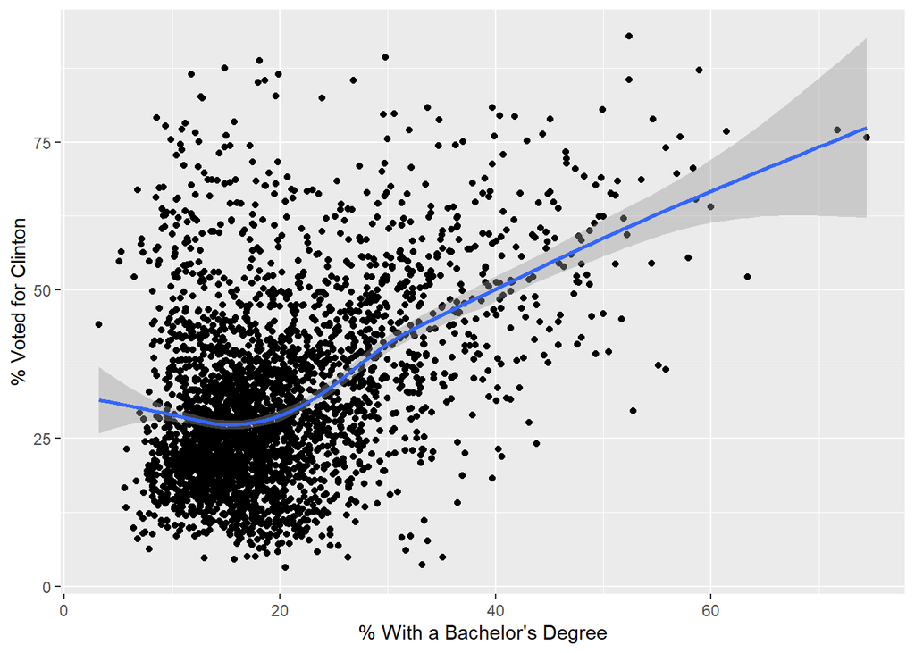

```r
ggplot(county_votes2, aes(x=pct_bachelors, y = pct_clinton)) + geom_point() + geom_smooth() + ylab("% Voted for Clinton") + xlab("% With a Bachelor's Degree")
```

Based on the scatterplot, it is hard to describe the association because it is very clustered but it does seem to have a positive association between the % of people with a Bachelor’s in a certain county and the % of voters that voted for Hillary Clinton.

## **Part E**

```r
county_votes_ca = county_votes2 %>% filter(state == "CA")
county_votes_ca
```

| fips | county | state | pop2014 | pct_bachelors | votes_clinton | votes_trump | total_votes | pct_clinton |
| --- | --- | --- | --- | --- | --- | --- | --- | --- |
| 6001 | Alameda County | CA | 1610921 | 41.8 | 486351 | 91189 | 613195 | 79.31425 |
| 6003 | Alpine County | CA | 1116 | 31.2 | 318 | 211 | 575 | 55.30435 |
| 6005 | Amador County | CA | 36742 | 19.3 | 5904 | 10239 | 17186 | 34.35354 |
| 6007 | Butte County | CA | 224241 | 24.4 | 38676 | 42193 | 87847 | 44.02655 |
| 6009 | Calaveras County | CA | 44624 | 21.2 | 7738 | 13072 | 22334 | 34.64673 |
| 6011 | Colusa County | CA | 21419 | 13.8 | 2518 | 3464 | 6346 | 39.67854 |
| 6013 | Contra Costa County | CA | 1111339 | 39.0 | 286658 | 105819 | 415972 | 68.91281 |
| 6015 | Del Norte County | CA | 27212 | 14.0 | 3485 | 5134 | 9361 | 37.22893 |
| 6017 | El Dorado County | CA | 183087 | 32.0 | 35243 | 47633 | 89228 | 39.49769 |
| 6019 | Fresno County | CA | 965974 | 19.6 | 123660 | 113949 | 250264 | 49.41182 |

[output cut: 48 more lines]

## **Part F**

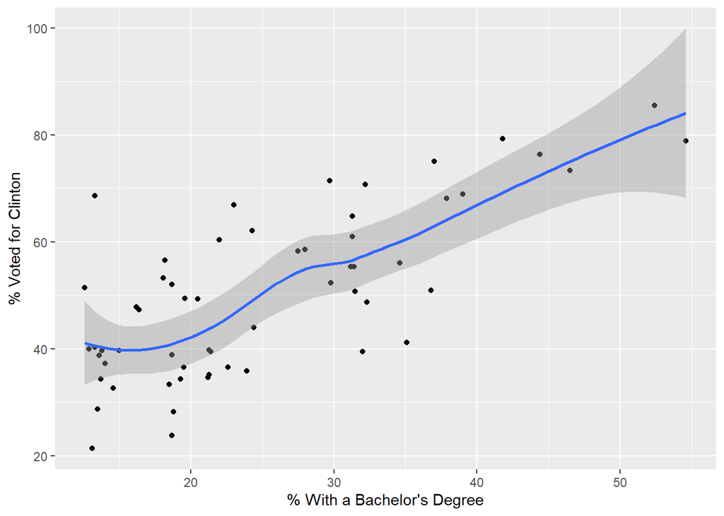

```r
ggplot(county_votes_ca, aes(x=pct_bachelors, y = pct_clinton)) + geom_point() + geom_smooth() + ylab("% Voted for Clinton") + xlab("% With a Bachelor's Degree")
```

In this scatter plot that only includes counties in California, there is a clear positive with the % of voters that have a Bachelor’s Degree and the % of voters that voted for Hillary Clinton.

# **Question 2**

```r
count = function(x) sum(is.na(x))
apply(airquality, 2, count)
```

```
##   Ozone Solar.R    Wind    Temp   Month     Day
##      37       7       0       0       0       0
```